# Final figures for manuscript

```r
na.count<-function(x) sum(is.na(x))
na.mean<-function(x) ifelse(is.nan(mean(x,na.rm=T)),NA,mean(x,na.rm=T))
```

#Defining the data I/O directory

```r
## change root.path as needed
root.path<-"C:\\Users\\tfens\\R_REPOS\\Flux_processing\\Concord_R_Code\\Concord_Post_Process\\"
# root.path<-"D:\\Housen\\Flux\\Data-exploring\\02_Concord_Eden\\"
#output folder
out.path<-paste0(root.path, "02_output\\08_manuscript_figures\\")
```

#load the RDA data produced in 12-Concord_bootstrap_GAMS_all #Housen uploaded the data as rda files to google drive.

```r
all_data <-  readRDS (file = "2022-04-20_all_data.rda" )

all_daily_data <- readRDS (file = "2022-04-20_all_data_daily.rda" )



all_filled_cum_matrix <- readRDS(file = "2022-04-20_all_filled_matrix.rda")

all_filled_matrix <- readRDS(file = "2022-04-20_all_filled_matrix.rda")

all_filled_matrix <- readRDS(file = "2022-04-20_all_predict_matrix.rda")
```

#creating 1/2 hour GPP control and treatment side values #sum(nee) = sum(gpp+reco) #sum (nee-reco)= sum (gpp)

```r
######Creating 1/2 hourly GPP variable for post compost##########

#control post compost(Reco predict_control mean or Reco_control_fin)
#Use Reco_predict control mean and force all nighttime GPP to zero.
all_data$all_post_data$GPP_control_mean <- (all_data$all_post_data$NEE_filled_control_mean - all_data$all_post_data$RECO_predict_control_mean)

summary(all_data$all_post_data$GPP_control_mean)
```

```
   Min. 1st Qu.  Median    Mean 3rd Qu.    Max.
-17.043  -2.746   0.000  -1.654   0.000   7.816
```

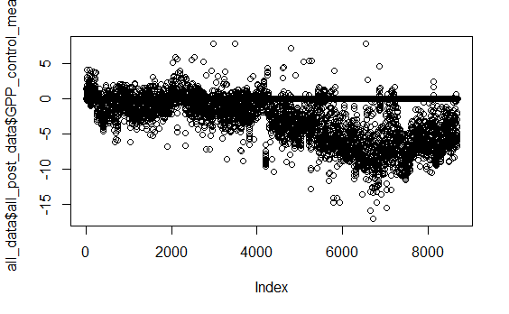

```r
plot(all_data$all_post_data$GPP_control_mean)
```

```r
#treatment post compost
all_data$all_post_data$GPP_treatment_mean<- (all_data$all_post_data$NEE_filled_treatment_mean - all_data$all_post_data$RECO_predict_treatment_mean  )

summary(all_data$all_post_data$GPP_treatment_mean)
```

```
    Min.  1st Qu.   Median     Mean  3rd Qu.     Max.
-20.2931  -4.2049  -0.5779  -2.0661   0.0000  11.4460
```

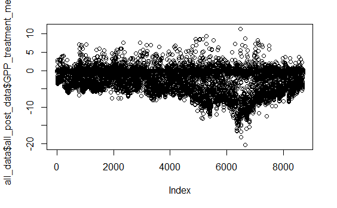

```r
plot(all_data$all_post_data$GPP_treatment_mean)
```

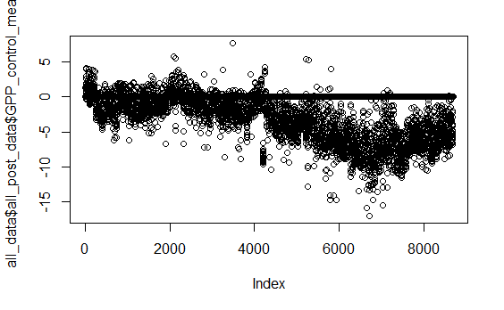

```r
#######Make all night time GPP zero############ #Need to do this if using reco_predict!

#night time defined as Rg<= 10

#control post compost
all_data$all_post_data$GPP_control_mean [(all_data$all_post_data$Rg <= 10 )]<-0

plot(all_data$all_post_data$GPP_control_mean)
```

```r
summary(all_data$all_post_data$GPP_control_mean)
```

```
   Min. 1st Qu.  Median    Mean 3rd Qu.    Max.
-17.043  -2.723   0.000  -1.653   0.000   7.765
```

```r
#treatment  post compost
all_data$all_post_data$GPP_treatment_mean [(all_data$all_post_data$Rg <= 10 )]<-0

##########95% CI for GPP#####################

#making 95% confidence intervals for GPP control post compost
all_data$all_post_data$GPP_control_q025 <- (all_data$all_post_data$NEE_predict_control_q025 - all_data$all_post_data$RECO_predict_control_q025)


all_data$all_post_data$GPP_control_q975 <- (all_data$all_post_data$NEE_predict_control_q975 - all_data$all_post_data$RECO_predict_control_q975)

#making 95% confidence intervals for GPP treatment post compost
all_data$all_post_data$GPP_treatment_q025 <- (all_data$all_post_data$NEE_predict_treatment_q025 - all_data$all_post_data$RECO_predict_treatment_q025)


all_data$all_post_data$GPP_treatment_q975 <- (all_data$all_post_data$NEE_predict_treatment_q975 - all_data$all_post_data$RECO_predict_treatment_q975)

##########plotting 1/2hourly Reco and GPP############

#control post compost
plot(all_data$all_post_data$TIMESTAMP[(all_data$all_post_data$Rg > 10 )], all_data$all_post_data$GPP_control_mean[(all_data$all_post_data$Rg > 10 )], col='green', ylim = c(-12,6))


par(new=TRUE)
```

```r
plot(all_data$all_post_data$TIMESTAMP, all_data$all_post_data$RECO_predict_control_mean , col='red', ylim = c(-12,6)
     )
par(new=TRUE)
```

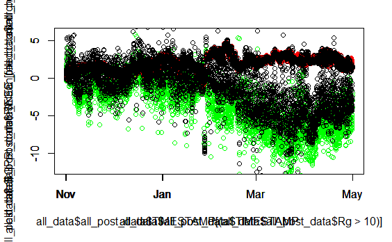

```r
plot(all_data$all_post_data$TIMESTAMP, all_data$all_post_data$NEE_filled_control_mean , ylim = c(-12,6))
```

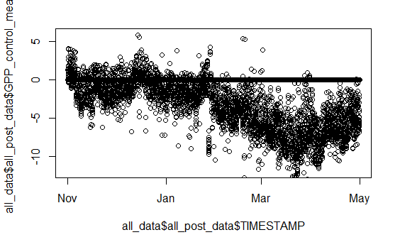

```r
plot(all_data$all_post_data$TIMESTAMP, all_data$all_post_data$GPP_control_mean, ylim = c(-12,6))
```

```r
#treatment post compost
plot(all_data$all_post_data$TIMESTAMP[(all_data$all_post_data$Rg > 10 )], all_data$all_post_data$GPP_treatment_mean[(all_data$all_post_data$Rg > 10 )], col='green', ylim = c(-12,6))


par(new=TRUE)
```

```r
plot(all_data$all_post_data$TIMESTAMP, all_data$all_post_data$RECO_predict_treatment_mean , col='red', ylim = c(-12,6)
     )
par(new=TRUE)
```

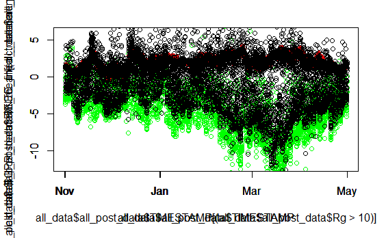

```r
plot(all_data$all_post_data$TIMESTAMP, all_data$all_post_data$NEE_filled_treatment_mean , ylim = c(-12,6))
```

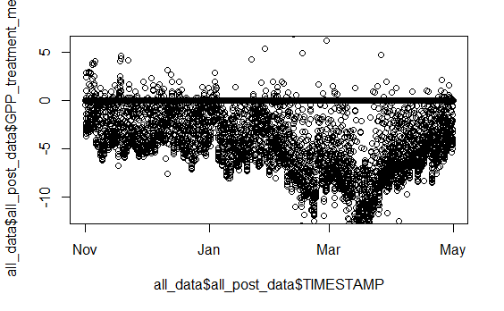

```r
plot(all_data$all_post_data$TIMESTAMP, all_data$all_post_data$GPP_treatment_mean, ylim = c(-12,6))
```

#GPP pre compost variable

```r
######Creating 1/2 hourly GPP variable##########

#control pre compost
all_data$all_pre_data$GPP_control_mean <- (all_data$all_pre_data$NEE_filled_control_mean - all_data$all_pre_data$RECO_predict_control_mean)

summary(all_data$all_pre_data$GPP_control_mean)
```

```
   Min. 1st Qu.  Median    Mean 3rd Qu.    Max.
-21.990  -6.307   0.000  -3.082   0.000  10.378
```

```r
#treatment pre compost
all_data$all_pre_data$GPP_treatment_mean<- (all_data$all_pre_data$NEE_filled_treatment_mean - all_data$all_pre_data$RECO_predict_treatment_mean  )

summary(all_data$all_pre_data$GPP_treatment_mean)
```

```
    Min.  1st Qu.   Median     Mean  3rd Qu.     Max.
-22.3992  -6.5691  -0.5098  -3.0324   0.0000  14.6568
```

```r
#######Make all night time GPP zero############ Need to do this since using Reco_predict_mean
#night time defined as Rg<= 10

# #control pre compost
all_data$all_pre_data$GPP_control_mean [(all_data$all_pre_data$Rg <= 10 )]<-0

# #treatment  pre compost
all_data$all_pre_data$GPP_treatment_mean [(all_data$all_pre_data$Rg <= 10 )]<-0

##########95% CI for GPP#####################

#making 95% confidence intervals for GPP control pre compost
all_data$all_pre_data$GPP_control_q025 <- (all_data$all_pre_data$NEE_predict_control_q025 - all_data$all_pre_data$RECO_predict_control_q025)


all_data$all_pre_data$GPP_control_q975 <- (all_data$all_pre_data$NEE_predict_control_q975 - all_data$all_pre_data$RECO_predict_control_q975)

#making 95% confidence intervals for GPP treatment pre compost
all_data$all_pre_data$GPP_treatment_q025 <- (all_data$all_pre_data$NEE_predict_treatment_q025 - all_data$all_pre_data$RECO_predict_treatment_q025)


all_data$all_pre_data$GPP_treatment_q975 <- (all_data$all_pre_data$NEE_predict_treatment_q975 - all_data$all_pre_data$RECO_predict_treatment_q975)
```

#Left side of Appendix figure showing observed and modeled treatment side post compost application

####panel (a) half-hourly non-gap filled and half hourly gap filled### #panel (b) daily GPP_treatment_mean and Respiration with error lines shaded

```r
col.code4 <- list(col.name = c( "treatment (modeled)","treatment (observed)"),

                  col = c("deepskyblue", "deepskyblue4"))

col.code5 <- list(col.name = c("Reco", "GPP"),

                  col3 = c("lightcoral", "lightgreen"))




#figure for cumulative and filled NEE and Reco

target.plot.var_nee <- c("NEE_filled_treatment_mean",
                         "GPP_treatment_mean",
                         "blank")

target.plot.var_nee.title <- c(
  expression(FC ~ '(' ~ mu ~ mol ~ m ^ {-2 } ~ s ^ { -1 } ~ ')'),
  expression(GPP ~ ';' ~ Reco~'(' ~ mu ~ mol ~ m ^ {-2 } ~ d ^ { -1 } ~ ')'),
  expression(Cumulative~sum~ '(' ~ g ~ C ~ m ^ {-2 } ~ ')')
)

## locate the start of each month
month.loc <- which(
  all_data$all_post_data$TIMESTAMP$mday == 1 &
    all_data$all_post_data$TIMESTAMP$hour == 0 &
    all_data$all_post_data$TIMESTAMP$min == 0
)
month.ticks <-
  substr(seq(
    all_data$all_post_data$TIMESTAMP[month.loc[1]],
    all_data$all_post_data$TIMESTAMP[month.loc[length(month.loc)]],
    by = "months"
  ), 6, 7)

## daily average values
daily_nee.tmp <-
  data.frame(
    date = tapply(
      all_data$all_post_data$time.id,
      all_data$all_post_data$Doy_water,
      min
    ),
    daily_nee = tapply(
      all_data$all_post_data$NEE_filled_treatment_mean,
      all_data$all_post_data$Doy_water,
      na.mean
    ),
    daily_gpp = tapply(
      all_data$all_post_data$GPP_treatment_mean,
      all_data$all_post_data$Doy_water,
      na.mean
    ),
    daily_reco = tapply(
      all_data$all_post_data$RECO_predict_treatment_mean,
      all_data$all_post_data$Doy_water,
      na.mean
    ),
    daily_gpp_q025 = tapply(
      all_data$all_post_data$GPP_treatment_q025,
      all_data$all_post_data$Doy_water,
      na.mean
    ),
    daily_gppq975 = tapply(
      all_data$all_post_data$GPP_treatment_q975,
      all_data$all_post_data$Doy_water,
      na.mean
    ),
    daily_reco025 = tapply(
      all_data$all_post_data$RECO_predict_treatment_q025,
      all_data$all_post_data$Doy_water,
      na.mean
    ),
    daily_reco975 = tapply(
      all_data$all_post_data$RECO_predict_treatment_q975,
      all_data$all_post_data$Doy_water,
      na.mean
    )
  )




## begin plot
png(
  paste0(out.path, "NEE_treatment_appendix_model_observed_daily",
    all_data$all_post_data$TIMESTAMP$year[1] + 1900, "_",
    all_data$all_post_data$TIMESTAMP$yday[1] + 1, "_",
    all_data$all_post_data$TIMESTAMP$year[nrow(all_data$all_post_data)] + 1900, "_",
    all_data$all_post_data$TIMESTAMP$yday[nrow(all_data$all_post_data)] + 1, "_",
    "NEE_",
    Sys.Date(), ".png"
  ),
  width = 5.5,
  height = 6,
  units = "in",
  res = 300,
  pointsize = 11,
  bg = "white"
)
par(oma = c(4, 4.5, 0.5, 0.5),
    mar = c(0, 0, 0.25, 0))

par(fig = c(0, 1, 1 /2, 1), new = FALSE)
plot(
  all_data[[2]]$time.id,
  all_data[[2]]$NEE_filled_treatment_mean,
  pch = 20,
  cex = 0.7,
  col = col.code4$col[1],
  las = 1,
  ylab = "",
  xlab = "",
  xaxt = "n",
  xaxs = "i",
  #yaxt = "n",
  ylim = c(-15, 15),
  cex.axis = 0.8
)

points(
  all_data[[2]]$time.id[all_data[[2]]$treatment == "treatment_post_compost"],
  all_data[[2]]$NEE[all_data[[2]]$treatment == "treatment_post_compost"],
  pch = 20,
  cex = 0.7,
  col = col.code4$col[2]
)

abline(
  v = 2020 + 290 / 366,
  col = "red",
  lwd = 2,
  lty = 4
)
abline(h = 0, col = "black")
abline(v = daily_nee.tmp$date[366], lwd= 1.5, col = "black")


#adding panel label
text(
  x = all_data$all_post_data$time.id[50],
  y = 13.5,
  paste0("(a)"),
  adj = c(0, 1),
  cex = 0.9
)

mtext(
  side = 2,
  target.plot.var_nee.title[[1]],
  line = 3,
  outer = FALSE,
  cex = 0.8
)

legend(
  "topleft",
  fill = col.code4$col,
  border = NA,
  legend = col.code4$col.name,
  ncol = 2,
  cex = 0.7,
  bty = "n"
)

## panel b
par(fig = c(0, 1, 0, 1 / 2), new = TRUE)
plot(
  daily_nee.tmp$date,
  daily_nee.tmp$daily_gpp,
  xlab = "",
  ylab = "",
  cex = 0,
  col = "forestgreen",
  bg = "forestgreen",
  xaxt = "n",
  las = 1,
  pch = 21,
  xaxs = "i",
  ylim = c(-10, 10),
  cex.axis = 0.8
)
```

```r
polygon(c(daily_nee.tmp$date,
          rev(daily_nee.tmp$date)),
        c(daily_nee.tmp$daily_reco975 ,
          rev(daily_nee.tmp$daily_reco025)),
        col = col.code5$col3[1],
        border = NA)
polygon(c(daily_nee.tmp$date,
          rev(daily_nee.tmp$date)),
        c(daily_nee.tmp$daily_gppq975 ,
          rev(daily_nee.tmp$daily_gpp_q025)),
        col = col.code5$col3[2],
        border = NA)
points(
  daily_nee.tmp$date,
  daily_nee.tmp$daily_reco,
  cex = 0.6,
  col = "red",
  bg = "red",
  pch = 21,
)

points(
  daily_nee.tmp$date,
  daily_nee.tmp$daily_gpp,
  cex = 0.6,
  col = "forestgreen",
  bg = "forestgreen",
  pch = 21,
)


abline(
  v = 2020 + 290 / 366,
  col = "red",
  lwd = 2,
  lty = 4
)
abline(h = 0, col = "black")
abline(v = daily_nee.tmp$date[366], lwd= 1.5, col = "black")

#adding panel label
text(
  x = all_data$all_post_data$time.id[50],
  y = 10,
  paste0("(b)"),
  adj = c(0, 1),
  cex = 0.9
)

mtext(
  side = 2,
  target.plot.var_nee.title[[2]],
  line = 3,
  outer = FALSE,
  cex = 0.8


)

axis(
  side = 1,
  at = all_data$all_post_data$time.id[month.loc],
  labels = month.ticks,
  tck = -.025,
  cex.axis = 0.8
)



axis(
  side = 1,
  at = c(2019.75, 2020.92, 2021.17),
  label = c(2019, 2020, 2021),
  cex.axis = 0.8,
  tck = -.025,
  lty = 0,
  bty = "n",
  line = 0.9
)

mtext(
  side = 1,
  "Month / Year",
  line = 3,
  outer = FALSE,
  cex = 0.8
)




dev.off()
```

# Right side of Appendix figure showing observed and modeled control side post compost application

####panel C half-hourly non-gap filled and half hourly gap filled### #panel D daily GPP_control_mean and Respiration with error lines shaded

```r
col.code3 <- list(col.name = c( "control (modeled)","control (observed)"),

                  col = c("firebrick1", "firebrick4"))



#figure for cumulative and filled NEE and Reco

target.plot.var_nee <- c("NEE_filled_control_mean",
                         "GPP_control_mean",
                         "blank")

target.plot.var_nee.title <- c(
  expression(FC ~ '(' ~ mu ~ mol ~ m ^ {-2 } ~ s ^ { -1 } ~ ')'),
  expression(GPP ~ ';' ~ Reco~'(' ~ mu ~ mol ~ m ^ {-2 } ~ d ^ { -1 } ~ ')'),
  expression(Cumulative~sum~ '(' ~ g ~ C ~ m ^ {-2 } ~ ')')
)

## locate the start of each month
month.loc <- which(
  all_data$all_post_data$TIMESTAMP$mday == 1 &
    all_data$all_post_data$TIMESTAMP$hour == 0 &
    all_data$all_post_data$TIMESTAMP$min == 0
)
month.ticks <-
  substr(seq(
    all_data$all_post_data$TIMESTAMP[month.loc[1]],
    all_data$all_post_data$TIMESTAMP[month.loc[length(month.loc)]],
    by = "months"
  ), 6, 7)


### daily average values
daily_nee.tmp_2 <-
  data.frame(
    date = tapply(
      all_data$all_post_data$time.id,
      all_data$all_post_data$Doy_water,
      min
    ),
    daily_nee = tapply(
      all_data$all_post_data$NEE_filled_control_mean,
      all_data$all_post_data$Doy_water,
      na.mean
    ),
    daily_gpp = tapply(
      all_data$all_post_data$GPP_control_mean,
      all_data$all_post_data$Doy_water,
      na.mean
    ),
    daily_reco = tapply(
      all_data$all_post_data$RECO_predict_control_mean,
      all_data$all_post_data$Doy_water,
      na.mean
    ),
    daily_gpp_q025 = tapply(
      all_data$all_post_data$GPP_control_q025,
      all_data$all_post_data$Doy_water,
      na.mean
    ),
    daily_gppq975 = tapply(
      all_data$all_post_data$GPP_control_q975,
      all_data$all_post_data$Doy_water,
      na.mean
    ),
    daily_reco025 = tapply(
      all_data$all_post_data$RECO_predict_control_q025,
      all_data$all_post_data$Doy_water,
      na.mean
    ),
    daily_reco975 = tapply(
      all_data$all_post_data$RECO_predict_control_q975,
      all_data$all_post_data$Doy_water,
      na.mean
    )
  )



## begin plot
png(
  paste0(out.path, "NEE_control_appendix_model_observed_daily",
    all_data$all_post_data$TIMESTAMP$year[1] + 1900, "_",
    all_data$all_post_data$TIMESTAMP$yday[1] + 1, "_",
    all_data$all_post_data$TIMESTAMP$year[nrow(all_data$all_post_data)] + 1900, "_",
    all_data$all_post_data$TIMESTAMP$yday[nrow(all_data$all_post_data)] + 1, "_",
    "NEE_",
    Sys.Date(), ".png"
  ),
  width = 5.5,
  height = 6,
  units = "in",
  res = 300,
  pointsize = 11,
  bg = "white"
)
par(oma = c(4, 4.5, 0.5, 0.5),
    mar = c(0, 0, 0.25, 0))

par(fig = c(0, 1, 1 /2, 1), new = FALSE)
plot(
  all_data[[2]]$time.id,
  all_data[[2]]$NEE_filled_control_mean,
  pch = 20,
  cex = 0.7,
  col = col.code3$col[1],
  las = 1,
  ylab = "",
  xlab = "",
  xaxt = "n",
  xaxs = "i",
  yaxt = "n",
  ylim = c(-15, 15),
  cex.axis = 0.8
)

points(
  all_data[[2]]$time.id[all_data[[2]]$treatment == "control_post_compost"],
  all_data[[2]]$NEE[all_data[[2]]$treatment == "control_post_compost"],
  pch = 20,
  cex = 0.7,
  col = col.code3$col[2]
)

abline(
  v = 2020 + 290 / 366,
  col = "red",
  lwd = 2,
  lty = 4
)
abline(h = 0, col = "black")
abline(v = daily_nee.tmp$date[366], lwd= 1.5, col = "black")

#adding panel label
text(
  x = all_data$all_post_data$time.id[50],
  y = 13.5,
  paste0("(c)"),
  adj = c(0, 1),
  cex = 0.9,

)





# mtext(
#   side = 2,
#   target.plot.var_nee.title[[1]],
#   line = 3,
#   outer = FALSE,
#   cex = 0.8
# )

legend(
  "topleft",
  fill = col.code3$col,
  border = NA,
  legend = col.code3$col.name,
  ncol = 2,
  cex = 0.7,
  bty = "n"
)

## panel b
par(fig = c(0, 1, 0, 1 / 2), new = TRUE)
plot(
  daily_nee.tmp_2$date,
  daily_nee.tmp_2$daily_gpp,
  xlab = "",
  ylab = "",
  cex = 0,
  col = "forestgreen",
  bg = "forestgreen",
  xaxt = "n",
  las = 1,
  pch = 21,
  xaxs = "i",
  yaxt = "n",
  ylim = c(-10, 10),
  cex.axis = 0.8
)
```

```r
polygon(c(daily_nee.tmp_2$date,
          rev(daily_nee.tmp_2$date)),
        c(daily_nee.tmp_2$daily_reco975 ,
          rev(daily_nee.tmp_2$daily_reco025)),
        col = col.code5$col3[1],
        border = NA)
polygon(c(daily_nee.tmp_2$date,
          rev(daily_nee.tmp_2$date)),
        c(daily_nee.tmp_2$daily_gppq975 ,
          rev(daily_nee.tmp_2$daily_gpp_q025)),
        col = col.code5$col3[2],
        border = NA)
points(
  daily_nee.tmp_2$date,
  daily_nee.tmp_2$daily_reco,
  cex = 0.6,
  col = "red",
  bg = "red",
  pch = 21,
)

points(
  daily_nee.tmp_2$date,
  daily_nee.tmp_2$daily_gpp,
  cex = 0.6,
  col = "forestgreen",
  bg = "forestgreen",
  pch = 21,
)


abline(
  v = 2020 + 290 / 366,
  col = "red",
  lwd = 2,
  lty = 4
)
abline(h = 0, col = "black")
abline(v = daily_nee.tmp$date[366], lwd= 1.5, col = "black")

text(
  x = all_data$all_post_data$time.id[50],
  y = 10,
  paste0("(d)"),
  adj = c(0, 1),
  cex = 0.9
)

# mtext(
#   side = 2,
#   target.plot.var_nee.title[[2]],
#   line = 3,
#   outer = FALSE,
#   cex = 0.8
#
#
# )

axis(
  side = 1,
  at = all_data$all_post_data$time.id[month.loc],
  labels = month.ticks,
  tck = -.025,
  cex.axis = 0.8
)

text(
  x = all_data$all_post_data$time.id[1],
  y = 1200,
  paste0("(c)"),
  adj = c(0, 1),
  cex = 0.9
)


axis(
  side = 1,
  at = c(2019.75, 2020.92, 2021.17),
  label = c(2019, 2020, 2021),
  cex.axis = 0.8,
  tck = -.025,
  lty = 0,
  bty = "n",
  line = 0.9
)

mtext(
  side = 1,
  "Month / Year",
  line = 3,
  outer = FALSE,
  cex = 0.8
)




dev.off()
```

#Figure three. First chunk of code will be for left panel which shows pre-compost application. Second chunk of codes will be for right panel which shows post-compost application cumulative sums.

#Figure 3. left panel. pre-compost application. **Top panel: NEE** **Middle panel: GPP** **Bottom panel: Reco**

```r
col.code2 <- list(col.name = c("control", "treatment"),
                  col = c("firebrick1", "deepskyblue"))

#figure for cumulative and filled NEE and Reco

target.plot.var_nee <- c("NEE_filled_treatment_mean",
                         "GPP_treatment_mean",
                         "blank")

target.plot.var_nee.title <- c(
   expression(Cumulative~sum~NEE~ '(' ~ g ~ C ~ m ^ {-2 } ~ ')'),
  expression(Cumulative~sum~GPP~ '(' ~ g ~ C ~ m ^ {-2 } ~ ')'),
  expression(Cumulative~sum~Reco~ '(' ~ g ~ C ~ m ^ {-2 } ~ ')')
)

## locate the start of each month
month.loc <- which(
  all_data$all_pre_data$TIMESTAMP$mday == 1 &
    all_data$all_pre_data$TIMESTAMP$hour == 0 &
    all_data$all_pre_data$TIMESTAMP$min == 0
)
month.ticks <-
  substr(seq(
    all_data$all_pre_data$TIMESTAMP[month.loc[1]],
    all_data$all_pre_data$TIMESTAMP[month.loc[length(month.loc)]],
    by = "months"
  ), 6, 7)

## daily average values treatment and control side
daily_nee.tmp_3 <-
  data.frame(
    date = tapply(
      all_data$all_pre_data$time.id,
      all_data$all_pre_data$Doy_water,
      min
    ),

    ############################################
    #Daily GPP and error ranges for the treatment side
    daily_gpp_treatment = tapply(
      all_data$all_pre_data$GPP_treatment_mean,
      all_data$all_pre_data$Doy_water,
      na.mean
    ),
    daily_gpp_treatment_q025 = tapply(
      all_data$all_pre_data$GPP_treatment_q025,
      all_data$all_pre_data$Doy_water,
      na.mean
    ),
    daily_gpp_treatment_q975 = tapply(
      all_data$all_pre_data$GPP_treatment_q975,
      all_data$all_pre_data$Doy_water,
      na.mean
    ),


    #################################################
    #Daily reco and error ranges for the treatment side
    daily_reco_treatment = tapply(
      all_data$all_pre_data$RECO_predict_treatment_mean,
      all_data$all_pre_data$Doy_water,
      na.mean
    ),
     daily_reco_treatment_q025 = tapply(
      all_data$all_pre_data$RECO_predict_treatment_q025,
      all_data$all_pre_data$Doy_water,
      na.mean
    ),
    daily_reco_treatment_q975 = tapply(
      all_data$all_pre_data$RECO_predict_treatment_q975,
      all_data$all_pre_data$Doy_water,
      na.mean
    ),

    ############################################

    #Daily GPP and error ranges for the control side
    daily_gpp_control = tapply(
      all_data$all_pre_data$GPP_control_mean,
      all_data$all_pre_data$Doy_water,
      na.mean
    ),
    daily_gpp_control_q025 = tapply(
      all_data$all_pre_data$GPP_control_q025,
      all_data$all_pre_data$Doy_water,
      na.mean
    ),
    daily_gpp_control_q975 = tapply(
      all_data$all_pre_data$GPP_control_q975,
      all_data$all_pre_data$Doy_water,
      na.mean
    ),

    #################################################

    #Daily reco and error ranges for the control side
   daily_reco_control = tapply(
      all_data$all_pre_data$RECO_predict_control_mean,
      all_data$all_pre_data$Doy_water,
      na.mean
    ),
     daily_reco_control_q025 = tapply(
      all_data$all_pre_data$RECO_predict_control_q025,
      all_data$all_pre_data$Doy_water,
      na.mean
    ),
    daily_reco_control_q975 = tapply(
      all_data$all_pre_data$RECO_predict_control_q975,
      all_data$all_pre_data$Doy_water,
      na.mean
    )
  )
############



## convert NEE, GPP, Reco to cumulative sum of carbon
# convert to cumulative carbon
for(ll in 2:13) {
  # convert to daily units
  daily_nee.tmp_3[, ll] <-
    daily_nee.tmp_3[, ll] * 12 / 1000000 * 1800 * 48
  daily_nee.tmp_3[is.na(daily_nee.tmp_3[, ll]), ll] <- 0

  # calculate cumulative sum, hard-coded with first/second years
  daily_nee.tmp_3[1:365, ll] <-
    cumsum(daily_nee.tmp_3[1:365, ll])
  daily_nee.tmp_3[366:nrow(daily_nee.tmp_3), ll] <-
    cumsum(daily_nee.tmp_3[366:nrow(daily_nee.tmp_3), ll])

  # set break (missing value) between two years
  daily_nee.tmp_3[366, ll] <- NA
}

## begin plot
png(
  paste0(out.path, "Cumulative_NEE_GPP_Reco_pre_compost_concord",
    all_data$all_pre_data$TIMESTAMP$year[1] + 1900, "_",
    all_data$all_pre_data$TIMESTAMP$yday[1] + 1, "_",
    all_data$all_pre_data$TIMESTAMP$year[nrow(all_data$all_pre_data)] + 1900, "_",
    all_data$all_pre_data$TIMESTAMP$yday[nrow(all_data$all_pre_data)] + 1, "_",
    "NEE_",
    Sys.Date(), ".png"
  ),
  width = 5.5,
  height = 6,
  units = "in",
  res = 300,
  pointsize = 11,
  bg = "white"
)
par(oma = c(4, 4.5, 0.5, 0.5),
    mar = c(0, 0, 0.25, 0))

par(fig = c(0, 1, 2 / 3, 1), new = FALSE)
plot(all_data[[1]]$time.id,
     all_data[[1]]$NEE_filled_cum_control_mean,

     type = "l",
     lwd=4,
     col = col.code2$col[1],
     las = 1,
     xaxt = "n",
     xaxs ="i",
     ylab = "",
     xlab = "",
     cex.axis = 0.8,
     ylim = c(-100, 250))


lines(all_data[[1]]$time.id,
       all_data[[1]]$NEE_filled_cum_treatment_mean,

      lty = 1,
     lwd=4,
       col = col.code2$col[2])
lines(all_data[[1]]$time.id,
      all_data[[1]]$NEE_filled_cum_control_q025,
      col = col.code2$col[1],
      lty = 2)
lines(all_data[[1]]$time.id,
      all_data[[1]]$NEE_filled_cum_control_q975,
      col = col.code2$col[1],
      lty = 2)
lines(all_data[[1]]$time.id,
      all_data[[1]]$NEE_filled_cum_treatment_q025,
      col = col.code2$col[2],
      lty = 2)
lines(all_data[[1]]$time.id,
      all_data[[1]]$NEE_filled_cum_treatment_q975,
      col = col.code2$col[2],
      lty = 2)

legend("topleft",
       fill = col.code2$col,
       border = NA,
       legend = col.code2$col.name,
       ncol = 2,
       cex = 0.75,
       bty = "n")
abline(h = 0, col = "black")

mtext(
  side = 2,
  at = 40,
  target.plot.var_nee.title[[1]],
  line = 3,
  outer = FALSE,
  cex = 0.6
)
text(
  x = all_data$all_pre_data$time.id[50],
  y = 190,
  paste0("(a)"),
  adj = c(0, 1),
  cex = 0.9
)


## panel b Cumulative GPP
par(fig = c(0, 1, 1 / 3, 2 / 3), new = TRUE)

plot(
  daily_nee.tmp_3$date,
  daily_nee.tmp_3$daily_gpp_treatment,
  type = "l",
     lwd=4,
     col = col.code2$col[2],
     las = 1,
     xaxt = "n",
     xaxs ="i",
     ylab = "",
     xlab = "",
  ylim = c(-800, 10),
  cex.axis = 0.8
)
```

```r
lines(daily_nee.tmp_3$date,
      daily_nee.tmp_3$daily_gpp_treatment_q025,
      lwd = 1,
     col = col.code2$col[2],
      lty = 2
      )

lines(daily_nee.tmp_3$date,
      daily_nee.tmp_3$daily_gpp_treatment_q975,
      lwd = 1,
     col = col.code2$col[2],
      lty = 2
      )

lines(daily_nee.tmp_3$date,
      daily_nee.tmp_3$daily_gpp_control,
      lwd = 4,
     col = col.code2$col[1],
      lty = 1
      )

lines(daily_nee.tmp_3$date,
      daily_nee.tmp_3$daily_gpp_control_q025,
      lwd = 1,
     col = col.code2$col[1],
      lty = 2
      )

lines(daily_nee.tmp_3$date,
      daily_nee.tmp_3$daily_gpp_control_q975,
      lwd = 1,
     col = col.code2$col[1],
      lty = 2
      )


mtext(
  side = 2,
  target.plot.var_nee.title[[2]],
  line = 3,
  outer = FALSE,
  cex = 0.6
)

text(
  x = all_data$all_pre_data$time.id[50],
  y = -120,
  paste0("(b)"),
  adj = c(0, 1),
  cex = 0.9
)

abline(h = 0, col = "black")



## panel c cumulative Reco
par(fig = c(0, 1, 0, 1 / 3), new = TRUE)

plot(
  daily_nee.tmp_3$date,
  daily_nee.tmp_3$daily_reco_treatment,
  type = "l",
     lwd=4,
     col = col.code2$col[2],
     xlab = "",
  ylab = "",
  xaxt = "n",
  las = 1,
  xaxs = "i",
  ylim = c(-30, 1500),
  cex.axis = 0.8
)

lines(daily_nee.tmp_3$date,
      daily_nee.tmp_3$daily_reco_treatment_q025,
      lwd = 1,
     col = col.code2$col[2],
      lty = 2
      )

lines(daily_nee.tmp_3$date,
      daily_nee.tmp_3$daily_reco_treatment_q975,
      lwd = 1,
     col = col.code2$col[2],
      lty = 2
      )

lines(daily_nee.tmp_3$date,
      daily_nee.tmp_3$daily_reco_control,
      lwd = 4,
     col = col.code2$col[1],
      lty = 1
      )

lines(daily_nee.tmp_3$date,
      daily_nee.tmp_3$daily_reco_control_q025,
      lwd = 1,
     col = col.code2$col[1],
      lty = 2
      )

lines(daily_nee.tmp_3$date,
      daily_nee.tmp_3$daily_reco_control_q975,
      lwd = 1,
     col = col.code2$col[1],
      lty = 2
      )







abline(h = 0, col = "black")


axis(
  side = 1,
  at = all_data$all_pre_data$time.id[month.loc],
  labels = month.ticks,
  tck = -.025,
  cex.axis = 0.8
)

text(
  x = all_data$all_pre_data$time.id[50],
  y = 1400,
  paste0("(c)"),
  adj = c(0, 1),
  cex = 0.9
)

mtext(
  side = 2,
  target.plot.var_nee.title[[3]],
  line = 3,
  outer = FALSE,
  cex = 0.6
)

axis(
  side = 1,
  at = c(2019.87, 2020.2),
  label = c(2019, 2020),
  cex.axis = 0.8,
  tck = -.025,
  lty = 0,
  bty = "n",
  line = 0.9
)

mtext(
  side = 1,
  " Month / Year",
  line = 3,
  outer = FALSE,
  cex = 0.8
)


dev.off()
```

#Figure 3 right panel. post compost application

**Top panel: NEE** **Middle panel: GPP** **Bottom panel: Reco**

```r
col.code2 <- list(col.name = c("control", "treatment"),
                  col = c("firebrick1", "deepskyblue"))

#figure for cumulative and filled NEE and Reco

target.plot.var_nee <- c("NEE_filled_treatment_mean",
                         "GPP_treatment_mean",
                         "blank")

target.plot.var_nee.title <- c(
   expression(Cumulative~sum~NEE~ '(' ~ g ~ C ~ m ^ {-2 } ~ ')'),
  expression(Cumulative~sum~GPP~ '(' ~ g ~ C ~ m ^ {-2 } ~ ')'),
  expression(Cumulative~sum~Reco~ '(' ~ g ~ C ~ m ^ {-2 } ~ ')')
)

## locate the start of each month
month.loc <- which(
  all_data$all_post_data$TIMESTAMP$mday == 1 &
    all_data$all_post_data$TIMESTAMP$hour == 0 &
    all_data$all_post_data$TIMESTAMP$min == 0
)
month.ticks <-
  substr(seq(
    all_data$all_post_data$TIMESTAMP[month.loc[1]],
    all_data$all_post_data$TIMESTAMP[month.loc[length(month.loc)]],
    by = "months"
  ), 6, 7)

## daily average values treatment and control side
daily_nee.tmp_4 <-
  data.frame(
    date = tapply(
      all_data$all_post_data$time.id,
      all_data$all_post_data$Doy_water,
      min
    ),

    ############################################
    #Daily GPP and error ranges for the treatment side
    daily_gpp_treatment = tapply(
      all_data$all_post_data$GPP_treatment_mean,
      all_data$all_post_data$Doy_water,
      na.mean
    ),
    daily_gpp_treatment_q025 = tapply(
      all_data$all_post_data$GPP_treatment_q025,
      all_data$all_post_data$Doy_water,
      na.mean
    ),
    daily_gpp_treatment_q975 = tapply(
      all_data$all_post_data$GPP_treatment_q975,
      all_data$all_post_data$Doy_water,
      na.mean
    ),


    #################################################
    #Daily reco and error ranges for the treatment side
    daily_reco_treatment = tapply(
      all_data$all_post_data$RECO_predict_treatment_mean,
      all_data$all_post_data$Doy_water,
      na.mean
    ),
     daily_reco_treatment_q025 = tapply(
      all_data$all_post_data$RECO_predict_treatment_q025,
      all_data$all_post_data$Doy_water,
      na.mean
    ),
    daily_reco_treatment_q975 = tapply(
      all_data$all_post_data$RECO_predict_treatment_q975,
      all_data$all_post_data$Doy_water,
      na.mean
    ),

    ############################################

    #Daily GPP and error ranges for the control side
    daily_gpp_control = tapply(
      all_data$all_post_data$GPP_control_mean,
      all_data$all_post_data$Doy_water,
      na.mean
    ),
    daily_gpp_control_q025 = tapply(
      all_data$all_post_data$GPP_control_q025,
      all_data$all_post_data$Doy_water,
      na.mean
    ),
    daily_gpp_control_q975 = tapply(
      all_data$all_post_data$GPP_control_q975,
      all_data$all_post_data$Doy_water,
      na.mean
    ),

    #################################################

    #Daily reco and error ranges for the control side
   daily_reco_control = tapply(
      all_data$all_post_data$RECO_predict_control_mean,
      all_data$all_post_data$Doy_water,
      na.mean
    ),
     daily_reco_control_q025 = tapply(
      all_data$all_post_data$RECO_predict_control_q025,
      all_data$all_post_data$Doy_water,
      na.mean
    ),
    daily_reco_control_q975 = tapply(
      all_data$all_post_data$RECO_predict_control_q975,
      all_data$all_post_data$Doy_water,
      na.mean
    )
  )
############



## convert NEE, GPP, Reco to cumulative sum of carbon
# convert to cumulative carbon
for(ll in 2:13) {
  # convert to daily units
  daily_nee.tmp_4[, ll] <-
    daily_nee.tmp_4[, ll] * 12 / 1000000 * 1800 * 48
  daily_nee.tmp_4[is.na(daily_nee.tmp_4[, ll]), ll] <- 0

  # calculate cumulative sum, hard-coded with first/second years
  daily_nee.tmp_4[1:365, ll] <-
    cumsum(daily_nee.tmp_4[1:365, ll])
  daily_nee.tmp_4[366:nrow(daily_nee.tmp_4), ll] <-
    cumsum(daily_nee.tmp_4[366:nrow(daily_nee.tmp_4), ll])

  # set break (missing value) between two years
  daily_nee.tmp_4[366, ll] <- NA
}

## begin plot
png(
  paste0(out.path, "Cumulative_NEE_GPP_Reco_post_compost_concord",
    all_data$all_post_data$TIMESTAMP$year[1] + 1900, "_",
    all_data$all_post_data$TIMESTAMP$yday[1] + 1, "_",
    all_data$all_post_data$TIMESTAMP$year[nrow(all_data$all_post_data)] + 1900, "_",
    all_data$all_post_data$TIMESTAMP$yday[nrow(all_data$all_post_data)] + 1, "_",
    "NEE_",
    Sys.Date(), ".png"
  ),
  width = 5.5,
  height = 6,
  units = "in",
  res = 300,
  pointsize = 11,
  bg = "white"
)
par(oma = c(4, 4.5, 0.5, 0.5),
    mar = c(0, 0, 0.25, 0))

par(fig = c(0, 1, 2 / 3, 1), new = FALSE)
plot(all_data[[2]]$time.id,
     all_data[[2]]$NEE_filled_cum_control_mean,

     type = "l",
     lwd=4,
     col = col.code2$col[1],
     las = 1,
     xaxt = "n",
     xaxs ="i",
     yaxt = "n",
     ylab = "",
     xlab = "",
     cex.axis = 0.8,
     ylim = c(-100, 250))


lines(all_data[[2]]$time.id,
       all_data[[2]]$NEE_filled_cum_treatment_mean,

      lty = 1,
     lwd=4,
       col = col.code2$col[2])
lines(all_data[[2]]$time.id,
      all_data[[2]]$NEE_filled_cum_control_q025,
      col = col.code2$col[1],
      lty = 2)
lines(all_data[[2]]$time.id,
      all_data[[2]]$NEE_filled_cum_control_q975,
      col = col.code2$col[1],
      lty = 2)
lines(all_data[[2]]$time.id,
      all_data[[2]]$NEE_filled_cum_treatment_q025,
      col = col.code2$col[2],
      lty = 2)
lines(all_data[[2]]$time.id,
      all_data[[2]]$NEE_filled_cum_treatment_q975,
      col = col.code2$col[2],
      lty = 2)

# legend("topleft",
#        fill = col.code2$col,
#        border = NA,
#        legend = col.code2$col.name,
#        ncol = 2,
#        cex = 0.75,
#        bty = "n")
abline(h = 0, col = "black")

# mtext(
#   side = 2,
#   at = 40,
#   target.plot.var_nee.title[[1]],
#   line = 3,
#   outer = FALSE,
#   cex = 0.6
# )
text(
  x = all_data$all_post_data$time.id[50],
  y = 190,
  paste0("(d)"),
  adj = c(0, 1),
  cex = 0.9
)


## panel b Cumulative GPP
par(fig = c(0, 1, 1 / 3, 2 / 3), new = TRUE)

plot(
  daily_nee.tmp_4$date,
  daily_nee.tmp_4$daily_gpp_treatment,
  type = "l",
     lwd=4,
     col = col.code2$col[2],
     las = 1,
     xaxt = "n",
     xaxs ="i",
      yaxt = "n",
     ylab = "",
     xlab = "",
  ylim = c(-800, 10),
  cex.axis = 0.8
)
```

```r
lines(daily_nee.tmp_4$date,
      daily_nee.tmp_4$daily_gpp_treatment_q025,
      lwd = 1,
     col = col.code2$col[2],
      lty = 2
      )

lines(daily_nee.tmp_4$date,
      daily_nee.tmp_4$daily_gpp_treatment_q975,
      lwd = 1,
     col = col.code2$col[2],
      lty = 2
      )

lines(daily_nee.tmp_4$date,
      daily_nee.tmp_4$daily_gpp_control,
      lwd = 4,
     col = col.code2$col[1],
      lty = 1
      )

lines(daily_nee.tmp_4$date,
      daily_nee.tmp_4$daily_gpp_control_q025,
      lwd = 1,
     col = col.code2$col[1],
      lty = 2
      )

lines(daily_nee.tmp_4$date,
      daily_nee.tmp_4$daily_gpp_control_q975,
      lwd = 1,
     col = col.code2$col[1],
      lty = 2
      )


# mtext(
#   side = 2,
#   target.plot.var_nee.title[[2]],
#   line = 3,
#   outer = FALSE,
#   cex = 0.6
# )

text(
  x = all_data$all_post_data$time.id[50],
  y = -120,
  paste0("(e)"),
  adj = c(0, 1),
  cex = 0.9
)

abline(h = 0, col = "black")



## panel c cumulative Reco
par(fig = c(0, 1, 0, 1 / 3), new = TRUE)

plot(
  daily_nee.tmp_4$date,
  daily_nee.tmp_4$daily_reco_treatment,
  type = "l",
     lwd=4,
     col = col.code2$col[2],
     xlab = "",
  ylab = "",
  xaxt = "n",
  las = 1,
  xaxs = "i",
  yaxt = "n",
  ylim = c(-30, 1500),
  cex.axis = 0.8
)

lines(daily_nee.tmp_4$date,
      daily_nee.tmp_4$daily_reco_treatment_q025,
      lwd = 1,
     col = col.code2$col[2],
      lty = 2
      )

lines(daily_nee.tmp_4$date,
      daily_nee.tmp_4$daily_reco_treatment_q975,
      lwd = 1,
     col = col.code2$col[2],
      lty = 2
      )

lines(daily_nee.tmp_4$date,
      daily_nee.tmp_4$daily_reco_control,
      lwd = 4,
     col = col.code2$col[1],
      lty = 1
      )

lines(daily_nee.tmp_4$date,
      daily_nee.tmp_4$daily_reco_control_q025,
      lwd = 1,
     col = col.code2$col[1],
      lty = 2
      )

lines(daily_nee.tmp_4$date,
      daily_nee.tmp_4$daily_reco_control_q975,
      lwd = 1,
     col = col.code2$col[1],
      lty = 2
      )







abline(h = 0, col = "black")


axis(
  side = 1,
  at = all_data$all_post_data$time.id[month.loc],
  labels = month.ticks,
  tck = -.025,
  cex.axis = 0.8
)

text(
  x = all_data$all_post_data$time.id[50],
  y = 1400,
  paste0("(f)"),
  adj = c(0, 1),
  cex = 0.9
)

# mtext(
#   side = 2,
#   target.plot.var_nee.title[[3]],
#   line = 3,
#   outer = FALSE,
#   cex = 0.6
# )

axis(
  side = 1,
  at = c(2020.87, 2021.2),
  label = c(2020, 2021),
  cex.axis = 0.8,
  tck = -.025,
  lty = 0,
  bty = "n",
  line = 0.9
)

mtext(
  side = 1,
  " Month / Year",
  line = 3,
  outer = FALSE,
  cex = 0.8
)


dev.off()
```